# Customer Churn Prediction — Logistic Regression

A Complete Teaching Notebook | From Raw Data to Confident Interpretation

Instructor Edition

2026-04-21

# 1 Welcome — What This Notebook Teaches

This notebook teaches logistic regression from first principles using a real-world telecom churn dataset. Every decision — why we convert the outcome to a factor, why we normalise features, which loss function the model minimises — is explained before any code is written. By the end you will know not just *how* to run logistic regression in R, but *why* every step exists.

## 1.1 The Business Problem

A telecom company needs to answer one question: which customers are likely to cancel their subscription (churn)? Predicting churn before it happens allows the business to intervene — offer discounts, improve service, or reach out proactively — and protect revenue.

This is a **supervised binary classification** problem.

| Label | Meaning |
| --- | --- |
| `1` (becomes `"Yes"`) | Customer churned — cancelled their service |
| `0` (becomes `"No"`) | Customer stayed — did not cancel |

## 1.2 Why Logistic Regression, Not Linear Regression?

**Linear regression predicts a continuous number** — house price, temperature, revenue. Forced to predict churn, it can output values such as `1.8` or `-0.3`, which are not valid probabilities.

**Logistic regression** wraps the linear predictor inside a sigmoid function that maps any real number into the interval (0, 1):

$$P(\text{churn} = 1 \mid \mathbf{x}) = \frac{1}{1 + e^{-(\beta_0 + \beta_1 x_1 + \cdots + \beta_k x_k)}}$$

Taking the log-odds (logit) of that probability recovers linearity:

$$\text{logit}(p) = \log\!\left(\frac{p}{1-p}\right) = \beta_0 + \beta_1 x_1 + \cdots + \beta_k x_k$$

Logistic regression is a linear model — but it operates in log-odds space, and the sigmoid back-transformation ensures every output is a valid probability.

## 1.3 Roadmap

[output not shown]

# 2 Step 1 — Load Libraries

Load all packages at the very top of the notebook. This makes every dependency explicit and prevents cryptic “function not found” errors that appear mid-analysis when a package was never loaded.

```r
# ── Core data wrangling and visualisation ──────────────────────────────────────
library(tidyverse)     # dplyr, ggplot2, readr, tidyr, purrr, forcats
library(corrplot)      # heat-map style correlation matrix
library(scales)        # nice axis labels: percent(), comma(), dollar()

# ── Machine-learning pipeline ──────────────────────────────────────────────────
library(caret)         # createDataPartition(), preProcess(), confusionMatrix()

# ── Model evaluation ───────────────────────────────────────────────────────────
library(pROC)          # roc(), auc() — ROC curve and AUC-ROC metric
library(MLmetrics)     # LogLoss() — the loss function logistic regression minimises

# ── Coefficient interpretation ─────────────────────────────────────────────────
library(broom)         # tidy() — turns messy glm() output into a clean data frame

# ── Table formatting ───────────────────────────────────────────────────────────
library(knitr)         # kable() — renders clean HTML tables in the notebook
library(kableExtra)    # row/column-level styling for kable tables

cat("All libraries loaded successfully.\n")
```

```
All libraries loaded successfully.
```

# 3 Step 2 — Load and Explore the Data

Never skip exploratory data analysis. A model is only as good as your understanding of the data. EDA reveals missing values, unusual ranges, class imbalance, and which features look promising — all before you touch the model.

## 3.1 2a — Load the Dataset

```r
# read_csv() from readr (part of tidyverse) is faster and more type-consistent
# than base R's read.csv(). Critically, it never silently converts strings to
# factors, which avoids a whole class of subtle bugs.
#
# IMPORTANT: ChurnData.csv must be in your R working directory.
#   Check your current directory  :  getwd()
#   Change it                     :  setwd("path/to/your/folder")
#                                    or use the Files pane in RStudio.

df <- read_csv("ChurnData.csv")

cat("-----------------------------------\n")
cat(" DATASET OVERVIEW\n")
```

```
 DATASET OVERVIEW
```

```r
cat("-----------------------------------\n")
cat(sprintf("  Rows    : %d customers\n",  nrow(df)))
```

```
  Rows    : 200 customers
```

```r
cat(sprintf("  Columns : %d features\n\n", ncol(df)))
```

```
  Columns : 28 features
```

```r
# Display the first six rows as a formatted table for a quick sanity check
head(df) %>%
  kable(caption = "First 6 rows of ChurnData") %>%
  kable_styling(
    bootstrap_options = c("striped", "hover", "condensed"),
    full_width = FALSE,
    font_size  = 12
  )
```

First 6 rows of ChurnData

| tenure | age | address | income | ed | employ | equip | callcard | wireless | longmon | tollmon | equipmon | cardmon | wiremon | longten | tollten | cardten | voice | pager | internet | callwait | confer | ebill | loglong | logtoll | lninc | custcat | churn |
| --- | --- | --- | --- | --- | --- | --- | --- | --- | --- | --- | --- | --- | --- | --- | --- | --- | --- | --- | --- | --- | --- | --- | --- | --- | --- | --- | --- |
| 11 | 33 | 7 | 136 | 5 | 5 | 0 | 1 | 1 | 4.40 | 20.75 | 0.0 | 15.25 | 35.7 | 42.00 | 211.45 | 125 | 1 | 1 | 0 | 1 | 1 | 0 | 1.482 | 3.033 | 4.913 | 4 | 1 |
| 33 | 33 | 12 | 33 | 2 | 0 | 0 | 0 | 0 | 9.45 | 0.00 | 0.0 | 0.00 | 0.0 | 288.80 | 0.00 | 0 | 0 | 0 | 0 | 0 | 0 | 0 | 2.246 | 3.240 | 3.497 | 1 | 1 |
| 23 | 30 | 9 | 30 | 1 | 2 | 0 | 0 | 0 | 6.30 | 0.00 | 0.0 | 0.00 | 0.0 | 157.05 | 0.00 | 0 | 0 | 0 | 0 | 0 | 1 | 0 | 1.841 | 3.240 | 3.401 | 3 | 0 |
| 38 | 35 | 5 | 76 | 2 | 10 | 1 | 1 | 1 | 6.05 | 45.00 | 50.1 | 23.25 | 64.9 | 239.55 | 1873.05 | 880 | 1 | 1 | 1 | 1 | 1 | 1 | 1.800 | 3.807 | 4.331 | 4 | 0 |
| 7 | 35 | 14 | 80 | 2 | 15 | 0 | 1 | 0 | 7.10 | 22.00 | 0.0 | 23.75 | 0.0 | 47.45 | 166.10 | 145 | 1 | 0 | 0 | 1 | 1 | 0 | 1.960 | 3.091 | 4.382 | 3 | 0 |
| 68 | 52 | 17 | 120 | 1 | 24 | 0 | 1 | 0 | 20.70 | 0.00 | 0.0 | 22.00 | 0.0 | 1391.05 | 0.00 | 1505 | 0 | 0 | 0 | 0 | 0 | 0 | 3.030 | 3.240 | 4.787 | 1 | 0 |

## 3.2 2b — Data Types and Structure

```r
# glimpse() is the tidyverse equivalent of str() or Python's df.info().
# It shows: column names, data types, and a short preview of values in each column.
#
# KEY OBSERVATION: All columns will likely show as <dbl> (numeric) —
# including 'churn'. That means 'churn' is stored as 0 / 1 integers,
# not as a category. We must fix this before modelling. Step 3 explains why.

glimpse(df)
```

```
Rows: 200
Columns: 28
$ tenure   <dbl> 11, 33, 23, 38, 7, 68, 42, 9, 35, 49, 56, 47, 56, 69, 16, 4, …
$ age      <dbl> 33, 33, 30, 35, 35, 52, 40, 21, 50, 51, 52, 40, 50, 51, 27, 3…
$ address  <dbl> 7, 12, 9, 5, 14, 17, 7, 1, 26, 27, 28, 16, 1, 11, 5, 16, 3, 3…
$ income   <dbl> 136, 33, 30, 76, 80, 120, 37, 17, 140, 63, 49, 127, 80, 438, …
$ ed       <dbl> 5, 2, 1, 2, 2, 1, 2, 2, 2, 4, 2, 4, 2, 4, 3, 5, 5, 5, 3, 1, 2…
$ employ   <dbl> 5, 0, 2, 10, 15, 24, 8, 2, 21, 19, 12, 12, 24, 23, 5, 6, 11, …
$ equip    <dbl> 0, 0, 0, 1, 0, 0, 1, 0, 0, 0, 0, 1, 0, 1, 0, 1, 1, 1, 1, 0, 0…
$ callcard <dbl> 1, 0, 0, 1, 1, 1, 1, 0, 1, 1, 1, 1, 1, 1, 0, 0, 0, 1, 1, 1, 1…
$ wireless <dbl> 1, 0, 0, 1, 0, 0, 1, 0, 0, 0, 0, 0, 1, 0, 0, 1, 0, 1, 0, 0, 0…
$ longmon  <dbl> 4.40, 9.45, 6.30, 6.05, 7.10, 20.70, 8.25, 2.90, 6.50, 12.85,…
$ tollmon  <dbl> 20.75, 0.00, 0.00, 45.00, 22.00, 0.00, 23.50, 0.00, 27.50, 25…
$ equipmon <dbl> 0.00, 0.00, 0.00, 50.10, 0.00, 0.00, 36.90, 0.00, 0.00, 0.00,…
$ cardmon  <dbl> 15.25, 0.00, 0.00, 23.25, 23.75, 22.00, 28.00, 0.00, 35.00, 1…
$ wiremon  <dbl> 35.70, 0.00, 0.00, 64.90, 0.00, 0.00, 37.40, 0.00, 0.00, 0.00…
$ longten  <dbl> 42.00, 288.80, 157.05, 239.55, 47.45, 1391.05, 399.15, 25.25,…
$ tollten  <dbl> 211.45, 0.00, 0.00, 1873.05, 166.10, 0.00, 950.65, 0.00, 1068…
$ cardten  <dbl> 125, 0, 0, 880, 145, 1505, 1190, 0, 1215, 635, 1215, 680, 106…
$ voice    <dbl> 1, 0, 0, 1, 1, 0, 1, 0, 0, 0, 0, 0, 1, 0, 0, 1, 0, 1, 0, 0, 0…
$ pager    <dbl> 1, 0, 0, 1, 0, 0, 0, 0, 0, 0, 0, 0, 1, 1, 0, 1, 1, 0, 0, 0, 0…
$ internet <dbl> 0, 0, 0, 1, 0, 0, 1, 0, 0, 1, 0, 1, 0, 1, 0, 1, 1, 1, 0, 0, 0…
$ callwait <dbl> 1, 0, 0, 1, 1, 0, 1, 0, 1, 1, 0, 0, 1, 0, 0, 1, 0, 0, 0, 1, 0…
$ confer   <dbl> 1, 0, 1, 1, 1, 0, 1, 0, 1, 0, 0, 0, 1, 1, 0, 1, 0, 1, 1, 1, 0…
$ ebill    <dbl> 0, 0, 0, 1, 0, 0, 1, 0, 0, 1, 0, 1, 0, 0, 0, 1, 1, 1, 1, 0, 0…
$ loglong  <dbl> 1.482, 2.246, 1.841, 1.800, 1.960, 3.030, 2.110, 1.065, 1.872…
$ logtoll  <dbl> 3.033, 3.240, 3.240, 3.807, 3.091, 3.240, 3.157, 3.240, 3.314…
$ lninc    <dbl> 4.913, 3.497, 3.401, 4.331, 4.382, 4.787, 3.611, 2.833, 4.942…
$ custcat  <dbl> 4, 1, 3, 4, 3, 1, 4, 1, 3, 2, 2, 2, 4, 4, 1, 4, 2, 2, 3, 3, 1…
$ churn    <dbl> 1, 1, 0, 0, 0, 0, 0, 0, 0, 0, 0, 0, 0, 0, 0, 1, 0, 0, 0, 1, 0…
```

## 3.3 2c — Summary Statistics

```r
# summary() provides the five-number summary (min, Q1, median, Q3, max)
# plus the mean for every numeric column.
#
# Things to look for:
#   - Wide numeric ranges (e.g. 'income' running 0 to 1600 vs a binary 0/1 flag).
#     This confirms that normalisation is essential before model training (Step 5).
#   - Any column where Min == Max: zero variance, carries no useful information.
#   - NA counts appearing in any column: missing values must be handled first.

summary(df)
```

```
     tenure           age           address          income
 Min.   : 1.00   Min.   :19.00   Min.   : 0.00   Min.   :   9.00
 1st Qu.:16.75   1st Qu.:31.00   1st Qu.: 3.00   1st Qu.:  31.00
 Median :33.50   Median :40.00   Median : 9.00   Median :  48.00
 Mean   :35.51   Mean   :41.16   Mean   :11.65   Mean   :  75.13
 3rd Qu.:55.25   3rd Qu.:51.00   3rd Qu.:18.00   3rd Qu.:  80.00
 Max.   :72.00   Max.   :76.00   Max.   :48.00   Max.   :1668.00
       ed            employ          equip          callcard        wireless
 Min.   :1.000   Min.   : 0.00   Min.   :0.000   Min.   :0.000   Min.   :0.00
 1st Qu.:2.000   1st Qu.: 3.00   1st Qu.:0.000   1st Qu.:0.000   1st Qu.:0.00
 Median :3.000   Median : 7.50   Median :0.000   Median :1.000   Median :0.00
 Mean   :2.825   Mean   :10.22   Mean   :0.425   Mean   :0.705   Mean   :0.29
 3rd Qu.:4.000   3rd Qu.:17.00   3rd Qu.:1.000   3rd Qu.:1.000   3rd Qu.:1.00
 Max.   :5.000   Max.   :44.00   Max.   :1.000   Max.   :1.000   Max.   :1.00
    longmon          tollmon         equipmon        cardmon
 Min.   : 1.100   Min.   : 0.00   Min.   : 0.00   Min.   :  0.00
 1st Qu.: 5.537   1st Qu.: 0.00   1st Qu.: 0.00   1st Qu.:  0.00
 Median : 8.250   Median : 0.00   Median : 0.00   Median : 12.50
 Mean   :11.789   Mean   :13.24   Mean   :15.78   Mean   : 14.36
 3rd Qu.:14.300   3rd Qu.:24.75   3rd Qu.:33.01   3rd Qu.: 20.75
 Max.   :62.300   Max.   :68.50   Max.   :63.25   Max.   :109.25
    wiremon          longten           tollten          cardten
 Min.   :  0.00   Min.   :   1.10   Min.   :   0.0   Min.   :   0.0
 1st Qu.:  0.00   1st Qu.:  79.34   1st Qu.:   0.0   1st Qu.:   0.0
 Median :  0.00   Median : 289.52   Median :   0.0   Median : 342.5
 Mean   : 12.22   Mean   : 577.77   Mean   : 507.0   Mean   : 650.7
 3rd Qu.: 23.46   3rd Qu.: 806.76   3rd Qu.: 724.2   3rd Qu.: 921.2
 Max.   :109.70   Max.   :4333.00   Max.   :4938.6   Max.   :7515.0
     voice           pager          internet       callwait         confer
 Min.   :0.000   Min.   :0.000   Min.   :0.00   Min.   :0.000   Min.   :0.00
 1st Qu.:0.000   1st Qu.:0.000   1st Qu.:0.00   1st Qu.:0.000   1st Qu.:0.00
 Median :0.000   Median :0.000   Median :0.00   Median :0.000   Median :0.00
 Mean   :0.295   Mean   :0.275   Mean   :0.44   Mean   :0.455   Mean   :0.46
 3rd Qu.:1.000   3rd Qu.:1.000   3rd Qu.:1.00   3rd Qu.:1.000   3rd Qu.:1.00
 Max.   :1.000   Max.   :1.000   Max.   :1.00   Max.   :1.000   Max.   :1.00
     ebill         loglong         logtoll          lninc          custcat
 Min.   :0.00   Min.   :0.095   Min.   :1.749   Min.   :2.197   Min.   :1.000
 1st Qu.:0.00   1st Qu.:1.712   1st Qu.:3.227   1st Qu.:3.434   1st Qu.:2.000
 Median :0.00   Median :2.110   Median :3.240   Median :3.871   Median :2.000
 Mean   :0.44   Mean   :2.193   Mean   :3.229   Mean   :3.951   Mean   :2.475
 3rd Qu.:1.00   3rd Qu.:2.660   3rd Qu.:3.240   3rd Qu.:4.382   3rd Qu.:3.000
 Max.   :1.00   Max.   :4.132   Max.   :4.227   Max.   :7.419   Max.   :4.000
     churn
 Min.   :0.00
 1st Qu.:0.00
 Median :0.00
 Mean   :0.29
 3rd Qu.:1.00
 Max.   :1.00
```

## 3.4 2d — Missing Value Audit

```r
# Missing values corrupt model training silently if left unaddressed.
# We audit every column before proceeding.

missing_counts <- colSums(is.na(df))

if (sum(missing_counts) == 0) {
  cat("No missing values found. Clean dataset — we can proceed.\n")
} else {
  cat("Missing values detected:\n")
  missing_counts[missing_counts > 0] %>%
    as.data.frame() %>%
    setNames("Missing Count") %>%
    kable(caption = "Columns with missing values") %>%
    kable_styling(bootstrap_options = "striped", full_width = FALSE)
}
```

```
No missing values found. Clean dataset — we can proceed.
```

# 4 Step 3 — Cast the Response Variable to a Factor

**This is one of the most commonly missed steps. It changes the model fundamentally.**

## 4.1 Why This Step Cannot Be Skipped

When `churn` is stored as numeric (0.0 / 1.0), R’s `glm()` treats it as a continuous outcome and fits **linear regression** — not logistic. The consequences are severe:

- Predictions are not bounded to [0, 1]; values like -0.2 or 1.4 are possible.
- Coefficients are estimated by ordinary least squares, not maximum likelihood.
- The sigmoid link function is never applied.

Converting `churn` to a **factor** explicitly signals to `glm()`: *“This is a categorical outcome with two levels — apply the binomial family and the logit link function.”*

```r
# ── BEFORE: numeric representation ────────────────────────────────────────────
cat("BEFORE casting:\n")
```

```
BEFORE casting:
```

```r
cat("  R class       :", class(df$churn), "\n")
```

```
  R class       : numeric
```

```r
cat("  Unique values :", paste(sort(unique(df$churn)), collapse = ", "), "\n\n")
```

```
  Unique values : 0, 1
```

```r
# ── Cast to factor ─────────────────────────────────────────────────────────────
# levels = c(0, 1)         Explicit ordering — 0 becomes the reference level.
# labels = c("No", "Yes")  Human-readable labels (much clearer in model output).
#
# WHY put "No" first?
# R treats the FIRST factor level as the reference (baseline) category.
# Every coefficient therefore represents the change in log-odds of "Yes" (churn)
# relative to "No" (no churn). This is the standard, intuitive interpretation.

df$churn <- factor(df$churn, levels = c(0, 1), labels = c("No", "Yes"))

# ── AFTER: factor representation ──────────────────────────────────────────────
cat("AFTER casting:\n")
```

```
AFTER casting:
```

```r
cat("  R class :", class(df$churn), "\n")
```

```
  R class : factor
```

```r
cat("  Levels  :", paste(levels(df$churn), collapse = " -> "), "\n\n")
```

```
  Levels  : No -> Yes
```

```r
cat("Class distribution:\n")
```

```
Class distribution:
```

```r
print(table(df$churn))
```

```
 No Yes
142  58
```

## 4.2 Class Balance Check

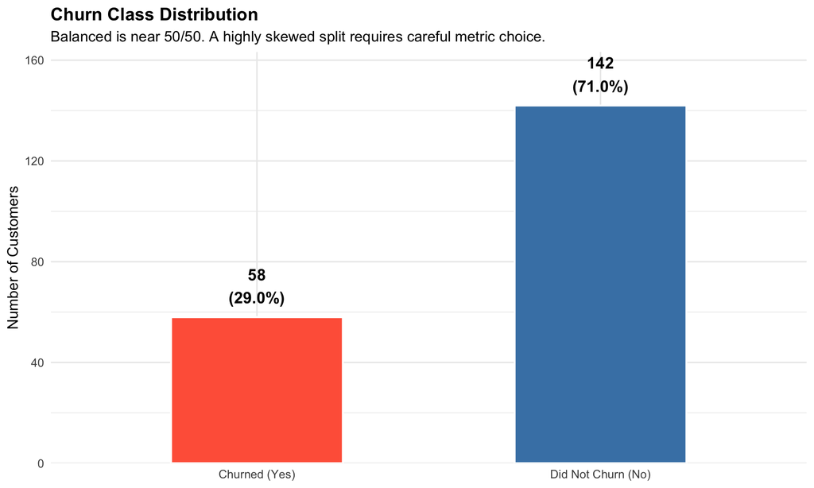

```r
# If 95% of customers are "No" and only 5% are "Yes", a naive model that
# always predicts "No" achieves 95% accuracy while being completely useless
# at identifying actual churners — the entire purpose of the model.
#
# A severe imbalance signals that:
#   - Accuracy is a misleading headline metric; prefer AUC-ROC and Log-Loss.
#   - Techniques like oversampling (SMOTE) or class weighting may be needed.

churn_counts       <- as.data.frame(table(df$churn))
names(churn_counts) <- c("Churn", "Count")
churn_counts$Pct   <- churn_counts$Count / sum(churn_counts$Count)
churn_counts$Label <- c("Did Not Churn (No)", "Churned (Yes)")

ggplot(churn_counts, aes(x = Label, y = Count, fill = Label)) +
  geom_col(width = 0.5, colour = "white", linewidth = 0.8) +
  geom_text(
    aes(label = paste0(Count, "\n(", percent(Pct, accuracy = 0.1), ")")),
    vjust = -0.4, fontface = "bold", size = 5
  ) +
  scale_fill_manual(
    values = c("Did Not Churn (No)" = "steelblue", "Churned (Yes)" = "tomato")
  ) +
  scale_y_continuous(expand = expansion(mult = c(0, 0.15))) +
  labs(
    title    = "Churn Class Distribution",
    subtitle = "Balanced is near 50/50. A highly skewed split requires careful metric choice.",
    x = NULL,
    y = "Number of Customers"
  ) +
  theme_minimal(base_size = 13) +
  theme(legend.position = "none", plot.title = element_text(face = "bold"))
```

**Interpretation:** If the split is severely unequal, overall accuracy is a misleading metric. This notebook evaluates the model with AUC-ROC and Log-Loss, which are robust to class imbalance and tell a more honest story.

# 5 Step 4 — Thoughtful Feature Selection

Including every column in your model is tempting but harmful. Irrelevant features add noise. Correlated features distort coefficient estimates. Feature selection is a deliberate craft, not an afterthought.

## 5.1 4a — Why Feature Selection Matters

| Problem | Consequence if ignored |
| --- | --- |
| Noise features | Model learns spurious patterns; generalises poorly to new data |
| Multicollinearity | Two correlated predictors share variance — coefficients become unstable and uninterpretable |
| Too many predictors | Risk of overfitting — model memorises training data, fails on test data |

## 5.2 4b — Point-Biserial Correlation With Churn

```r
# When one variable is binary (churn: 0/1) and the other is continuous,
# Pearson's r is mathematically equivalent to the point-biserial correlation
# — a valid measure of linear association between a continuous and a binary variable.
#
# Strategy: keep only features where |r| > 0.10 with churn.
# Features below this threshold have almost no linear relationship with the
# outcome and are unlikely to contribute meaningfully to the model.

# Temporarily restore churn to 0/1 numeric for the correlation calculation
churn_numeric <- as.numeric(df$churn) - 1   # "Yes"=2 -> 1, "No"=1 -> 0

# Identify all numeric predictor columns (churn itself excluded)
numeric_cols <- df %>%
  select(where(is.numeric)) %>%
  names()

# Compute the correlation of every numeric feature with churn
corr_with_churn <- sapply(numeric_cols, function(col) {
  cor(df[[col]], churn_numeric, use = "complete.obs")
})

# Build a sorted table — strongest absolute correlations at the top
corr_df <- tibble(
  Feature     = names(corr_with_churn),
  Correlation = corr_with_churn
) %>%
  arrange(desc(abs(Correlation)))

cat("Pearson correlation of each feature with 'churn' (sorted by absolute value):\n\n")
```

```
Pearson correlation of each feature with 'churn' (sorted by absolute value):
```

```r
corr_df %>%
  mutate(
    Correlation = round(Correlation, 3),
    Strength = case_when(
      abs(Correlation) >= 0.30 ~ "Strong",
      abs(Correlation) >= 0.10 ~ "Moderate",
      TRUE                     ~ "Weak — will be dropped"
    )
  ) %>%
  kable(caption = "Feature-Churn Correlation (point-biserial)") %>%
  kable_styling(bootstrap_options = c("striped", "hover"), full_width = FALSE) %>%
  row_spec(which(abs(corr_df$Correlation) <= 0.10), color = "grey")
```

Feature-Churn Correlation (point-biserial)

| Feature | Correlation | Strength |
| --- | --- | --- |
| tenure | -0.377 | Strong |
| employ | -0.338 | Strong |
| loglong | -0.337 | Strong |
| callcard | -0.311 | Strong |
| longten | -0.295 | Moderate |
| longmon | -0.292 | Moderate |
| age | -0.288 | Moderate |
| equip | 0.275 | Moderate |
| address | -0.261 | Moderate |
| equipmon | 0.255 | Moderate |
| internet | 0.255 | Moderate |
| ebill | 0.255 | Moderate |
| cardten | -0.229 | Moderate |
| ed | 0.216 | Moderate |
| wiremon | 0.177 | Moderate |
| cardmon | -0.177 | Moderate |
| wireless | 0.174 | Moderate |
| voice | 0.142 | Moderate |
| pager | 0.125 | Moderate |
| lninc | -0.117 | Moderate |
| income | -0.091 | Weak — will be dropped |
| confer | -0.081 | Weak — will be dropped |
| logtoll | -0.070 | Weak — will be dropped |
| tollten | -0.059 | Weak — will be dropped |
| callwait | -0.053 | Weak — will be dropped |
| custcat | 0.015 | Weak — will be dropped |
| tollmon | 0.014 | Weak — will be dropped |

## 5.3 4c — Visualise Correlations

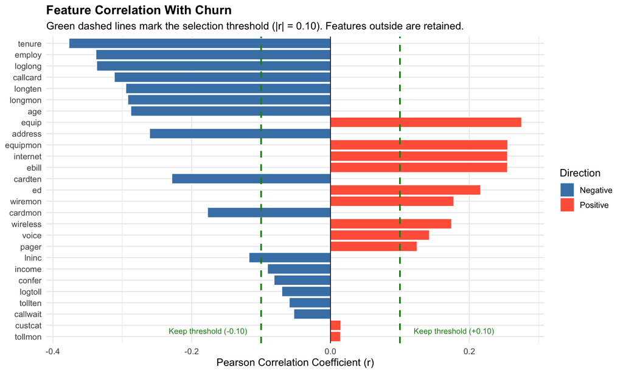

```r
# A horizontal bar chart makes the direction and magnitude of each relationship
# easy to read at a glance.

corr_df_plot <- corr_df %>%
  mutate(Direction = ifelse(Correlation > 0, "Positive", "Negative"))

ggplot(corr_df_plot,
       aes(x = Correlation,
           y = reorder(Feature, abs(Correlation)),
           fill = Direction)) +
  geom_col(colour = "white", linewidth = 0.4) +
  geom_vline(xintercept =  0.10, linetype = "dashed",
             colour = "forestgreen", linewidth = 0.9) +
  geom_vline(xintercept = -0.10, linetype = "dashed",
             colour = "forestgreen", linewidth = 0.9) +
  geom_vline(xintercept = 0, colour = "black", linewidth = 0.4) +
  scale_fill_manual(values = c("Negative" = "steelblue", "Positive" = "tomato")) +
  annotate("text", x =  0.12, y = 1.5, label = "Keep threshold (+0.10)",
           colour = "forestgreen", size = 3.2, hjust = 0) +
  annotate("text", x = -0.12, y = 1.5, label = "Keep threshold (-0.10)",
           colour = "forestgreen", size = 3.2, hjust = 1) +
  labs(
    title    = "Feature Correlation With Churn",
    subtitle = "Green dashed lines mark the selection threshold (|r| = 0.10). Features outside are retained.",
    x        = "Pearson Correlation Coefficient (r)",
    y        = NULL,
    fill     = "Direction"
  ) +
  theme_minimal(base_size = 12) +
  theme(plot.title = element_text(face = "bold"))
```